## (Ran-)Sackgang

Wir implementieren die [RANSAC-Methode](https://en.wikipedia.org/wiki/Random_sample_consensus) für lineare Modelle in einer Funktion `ransaclm` mit (mindestens) Argumenten `formula` (wie in `lm`), `data` (wie in `lm`), `error_threshold` (=$t$ im verlinkten Wikipedia-Artikel), `inlier_threshold` (=$d$ im verlinkten) und `iterations`.  
Was für zusätzliche Argumente benötigt die Funktion? (bitte erst selbst überlegen, dann Codebeispiel weiter unten anschauen…)

Unsere Funktion soll eine Liste mit Einträgen `model` und `data` zurückliefern:

- `model`: das gefundene beste Modell (ein `lm`-Objekt). `NULL` falls kein Modell gefunden wurde was den gegebenen thresholds entspricht.
- `data`: die für die Suche nach `model` verwendeten Daten, im Erfolgsfall ergänzt um eine `logical`-Spalte `.consensus_set` die das gefundene beste `consensus set` für `model` definiert.
1. *First, understand the problem. Then, write the code.* Skizzieren Sie zunächst in Pseudo-Code wie der RANSAC Algorithmus in Einzelschritte und Sub-Funktionen zergliedert werden kann. Definieren Sie sauber was jeweils die Inputs und Outputs dieser Sub-Funktionen sein sollen. Gehen Sie hier iterativ vor – verfeinern Sie sukzessive die grobe Untergliederung in kleinere Teilschritte.
- Denken Sie defensiv: Was könnte schiefgehen, wie gehen Sie sinnvoll damit um? Stichworte: Untaugliche Argumente, Daten mit fehlenden Werten, Faktorvariablen, lineare Modelle mit “$p > n$”, etc….
- Denken Sie parallel: Wie können Sie diesen Algorithmus am besten (plattformunabhängig) parallelisieren? (Welches Paket – `{future.apply}`, `{foreach}` + `{do??}`, `{parallel}` – Sie für die Parallelisierung benutzen bleibt Ihnen überlassen.)
2. Implementieren Sie Ihren Entwurf aus a).
3. Überprüfen Sie Ihre Implementation (auch) mit dem untenstehenden Testcode auf Korrektheit, Ihre Funktion sollte (ungefähr, da stochastischer Algorithmus!) das selbe Ergebnis produzieren.  
   Überlegen Sie sich weitere Testfälle für Komplikationen die bei der Anwendung auf echte Daten auftauchen könnten und überprüfen Sie Ihre Funktion damit. Schreiben Sie dafür entsprechende `expectations` mit den in `testthat` und/oder `checkmate` implementierten `expect_<BLA>()`-Funktionen.

**Wie immer gilt: Schreiben Sie sauber strukturierten, dokumentierten, kommentierten & funktionalen Code der für erwartbare Fehler und ungeeignete Inputs informative Fehlermeldungen und Warnungen produziert.**

#### Testcode:

Wir schreiben also zusätzlich

- eine Funktion die Daten aus einem linearen Modell mit klaren Outliern generiert um Testdatensätze zur Überprüfung unserer Funktion zu erzeugen, sowie
- eine Funktion die die `ransaclm`-Ergebnisse zusammenfasst und für univariate Modelle das Ergebnis visualisiert.

Das könnte etwa so aussehen:

```r
# generate toy data with very clear inlier / outlier distinction to
# validate ransaclm. intercept is 0, coefs have value 1.
# inputs: as named -- number  of observations, number of coefs, fraction of inliers
# output: a data.frame with columns y, x.1, ..., x.<n_coef>, inlier
make_ransac_data <- function(n_obs, n_coef, inlier_fraction = 0.7) {
  coef <- rep(1, n_coef)
  design <- matrix(runif(n_obs * n_coef), n_obs, n_coef)
  inlier <- sample(
    c(TRUE, FALSE)[c(
      rep(1, n_obs * inlier_fraction),
      rep(2, n_obs - n_obs * inlier_fraction)
    )]
  )
  # E(y) = design %*% coef if inlier, else random draw from
  # uniform dist. on [-10 * n_coef, -2 * n_coef] and [2 * n_coef, 10 * n_coef].
  # error variance = n_coef * Var(U[0,1])
  inlier_expected_y <- design %*% coef
  outlier_expected_y <- sample(c(-1, 1), n_obs, replace = TRUE) *
    runif(n_obs, min = 2 * n_coef, max = 10 * n_coef)
  y <- ifelse(inlier, inlier_expected_y, outlier_expected_y) +
    rnorm(n_obs, sd = sqrt(1 / 12 * n_coef))
  data.frame(y, x = design, inlier)
}

#-------------------------------------------------------------------------------

# summarize & visualize ransaclm() results on data from "make_ransac_data". Only
# works if ransaclm's output list has a "data" entry with columns "inlier" as
# generated by make_ransac_data() as well as a column ".consensus_set" flagging
# the observations in the consensus set found by RANSAC.
validate_ransac <- function(ransacmodel, plot = TRUE) {
  checkmate::assert_class(ransacmodel[["model"]], "lm")
  checkmate::assert_data_frame(ransacmodel[["data"]])
  data <- ransacmodel[["data"]]
  checkmate::assert_logical(data[, "inlier"], any.missing = FALSE)
  checkmate::assert_logical(data[, ".consensus_set"], any.missing = FALSE)

  consensus_set <- data[, ".consensus_set"]
  true_inliers <- data[, "inlier"]
  cat("Inlier:\n")
  print(table(true = true_inliers, estimated = consensus_set))
  cat("\nCoefficients: (should be intercept ~0, effects ~1)\n")
  print(summary(ransacmodel[["model"]])$coefficients)
  if (plot &
      (!all(c("x", "y") %in% names(data)))) {
    warning("Can't plot this data, expecting columns 'x' and 'y'.")
    plot <- FALSE
  }
  if (plot) {
    plot_ransac(ransacmodel, data)
  }
  invisible(ransacmodel)
}

plot_ransac <- function(ransacmodel, data) {
  colors <- c(
    black = rgb(0, 0, 0, .5), red = rgb(1, 0, 0, .5),
    blue = rgb(0, 0, 1, .5)
  )
  # scatterplot with true inliers in red, estimated inliers in blue
  # true regression line in black, RANSAC model in blue
  with(data,
       plot(x, y, col = colors[inlier + 1], pch = 19, bty = "n"))
  abline(c(0, 1), lwd = 2, col = colors[1])
  abline(ransacmodel$model, col = colors[3], lty = 2, lwd = 2)
  with(subset(data, .consensus_set),
       points(x, y, pch = 4, cex = 1.5, col = colors[3]))
  legend("top",
         lty = c(NA, NA, 1, 2, NA), lwd = c(NA, NA, 2, 2, NA),
         pch = c(19, 19, NA, NA, 4), col = colors[c(1, 2, 1, 3, 3)],
         legend = c(
           "'true' outliers", "'true' inliers", "true regression line",
           "RANSAC estimate", "RANSAC consensus set"
         ),
         cex = .7, bg = NA, inset = c(0, -.15), ncol = 3, xpd = NA
  )
}
```

Natürlich können Sie das obenstehende an Ihre Implementation anpassen oder sich auch ähnliche Funktionen selbst basteln.

Ihre Implementation sollte dann – in etwa – folgendes Verhalten reproduzieren:

```r
# immer set.seed() um Ergebnisse reproduzierbar zu machen...
set.seed(1874374111)
data_simple <- make_ransac_data(n_obs = 100, n_coef = 1, inlier_fraction = 0.7)

# univariate example:
ransac_simple <- ransaclm(y ~ . - inlier,
                          data = data_simple, error_threshold = 2,
                          inlier_threshold = 50, seed = 20171111
)
validate_ransac(ransac_simple)
```

```
## Inlier:
##        estimated
## true    FALSE TRUE
##   FALSE    29    1
##   TRUE      0   70
##
## Coefficients: (should be intercept ~0, effects ~1)
##                 Estimate Std. Error     t value     Pr(>|t|)
## (Intercept) -0.004682032 0.07126436 -0.06569948 9.478071e-01
## x            1.112400629 0.11695112  9.51167117 3.525077e-14
```

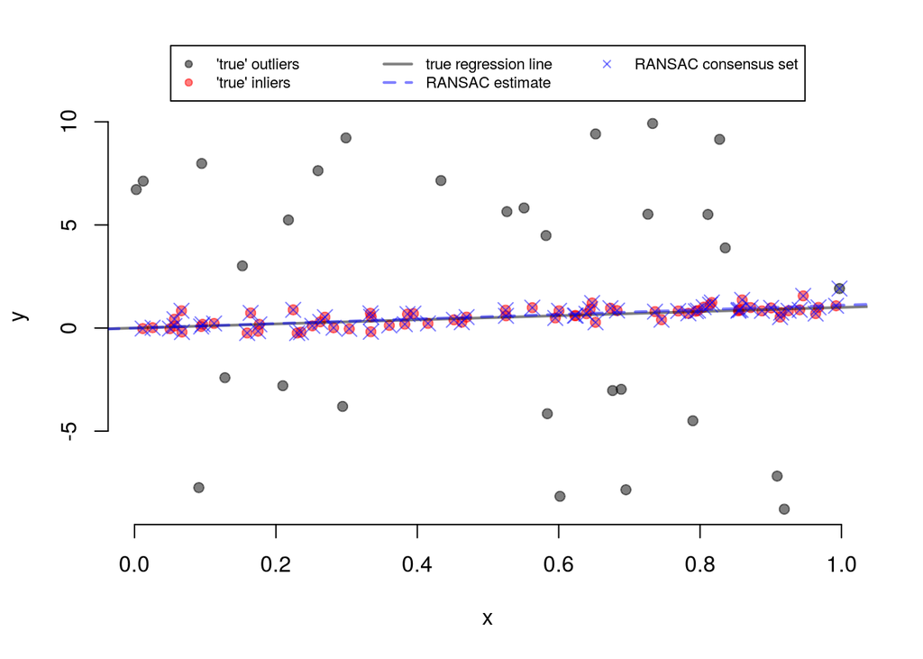

Hinweis 1: Durch die Formelnotation mit “`- inlier`” bleibt – in meiner Implementation, zumindest – die ursprünglich angelegte `inlier`-Variable, welche die wahren *inlier* identifiziert, im Datensatz des Rückgabeobjekts erhalten so dass wir mit `validate_ransac` eine Kreuztabelle der wahren und entdeckten Inlier/Outlier erzeugen können.

Hinweis 2: Es ist zu erwarten dass Parallelisierung hier wenn überhaupt nur bei recht großen Datensätzen Zeitvorteile bringt, in meiner Testimplementation sehe ich zB bei `n_obs = 100000, n_coef = 10` und 20 (!) parallelen Prozessen nur etwa eine Halbierung der Rechenzeit gegenüber einer sequentiellen Berechnung…